# Analysis of snRNAseq Data from Human and Chimp Skeletal Muscle Cells

PIs of the project are Ola Hansson, Lund University, and Svante Pääbo, Max-Planck Institute Leipzig

Nikolay Oskolkov, NBIS SciLifeLab, nikolay.oskolkov@scilifelab.se

April 29, 2019

Abstract

In this document we will apply Seurat pipeline to 10X snRNAseq data from human and chimp skeletal muscles cells. More specifically, we will check whether we find clustering with respect to skeletal muscle type 1 and type 2A / 2X fibrotypes. This analysis was published in Skeletal Muscle in 2022, https://skeletalmusclejournal.biomedcentral.com/articles/10.1186/s13395-022-00299-4, if you use the data for your research, we kindly ask you to cite the study.

### Reading and Filtering Data

Let us start with loading packages:

```r
library("Seurat")
library("dplyr")
library("data.table")
library("matrixStats")
```

Now we will load Skeletal Muscle scRNAseq un-normalized data and have a look:

```r
expr <- suppressWarnings(as.data.frame(fread("unzip -p SkeletalMuscle_HumanChimp_10X.zip",sep="\t")))
rownames(expr)<-expr$V1; expr$V1<-NULL;
expr <- expr[rowSums(expr) != 0,]
expr[1:5,1:5]
```

```
##               C00001_chimp C00004_human C00005_human C00006_chimp C00007_chimp
## RP11.34P13.7             0            0            0            0            0
## FO538757.2               0            0            0            0            0
## AP006222.2               0            0            0            0            0
## RP4.669L17.10            0            0            0            0            0
## RP5.857K21.4             0            0            0            0            0
```

```r
print(paste0("DATASET CONTAINS ",dim(expr)[1]," GENES AND ",dim(expr)[2]," CELLS"))
```

```
## [1] "DATASET CONTAINS 18104 GENES AND 6578 CELLS"
```

As previously, we will exclude MALAT1 and ribosomal genes:

```r
expr<-expr[-which(rownames(expr)=="MALAT1"),]
expr<-expr[grepl(paste0(c("^RPS","^RPL"),collapse="|"),rownames(expr))==FALSE,]
```

Now let us display mitochondrial genes:

```r
rownames(expr)[grepl("^MT\\.",rownames(expr))]
```

```
##  [1] "MT.ND1"  "MT.ND2"  "MT.CO1"  "MT.CO2"  "MT.ATP8" "MT.ATP6" "MT.CO3"
##  [8] "MT.ND3"  "MT.ND4L" "MT.ND4"  "MT.ND5"  "MT.ND6"  "MT.CYB"
```

Here we are going to filter out the contaminated nuclei with >1% of their UMIs due to mitochondrial genes:

```r
mito_genes_expr_matrix <- expr[rownames(expr)[grepl("^MT\\.",rownames(expr))],]
percent_mito_expr <- colSums(mito_genes_expr_matrix) / colSums(expr)
expr[,names(percent_mito_expr[percent_mito_expr>0.01])] <- NULL
```

Now everything is ready for running the Seurat pipeline. We should not see lots of cells with mitochondrial contamination at the end.

### Performing Quality Control

The steps below encompass the standard pre-processing workflow for scRNA-seq data in Seurat. These represent the creation of a Seurat object, the selection and filtration of cells based on QC metrics, data normalization and scaling, and the detection of highly variable features.

```r
skm <- CreateSeuratObject(counts = expr, project = "SKM", min.cells = 1, min.features = 0, meta.data=data.frame(row.names=colnames(expr),orig.ident=matrix(unlist(strsplit(colnames(expr),"_")),ncol=2,byrow=TRUE)[,2]))
skm@active.ident<-as.factor(skm$orig.ident)
skm
```

```
## An object of class Seurat
## 17676 features across 5668 samples within 1 assay
## Active assay: RNA (17676 features, 0 variable features)
##  1 layer present: counts
```

The number of features and UMIs (nFeature_RNA and nCount_RNA) are automatically calculated for every object by Seurat. For non-UMI data, nCount_RNA represents the sum of the non-normalized values within a cell i.e. library size. nFeature_RNA is a number of non-zero counts per cell. We calculate the percentage of mitochondrial features here and store it in object metadata as *percent.mito*. We use raw count data since this represents non-transformed and non-log-normalized counts. The % of UMI mapping to MT-features is a common scRNA-seq QC metric.

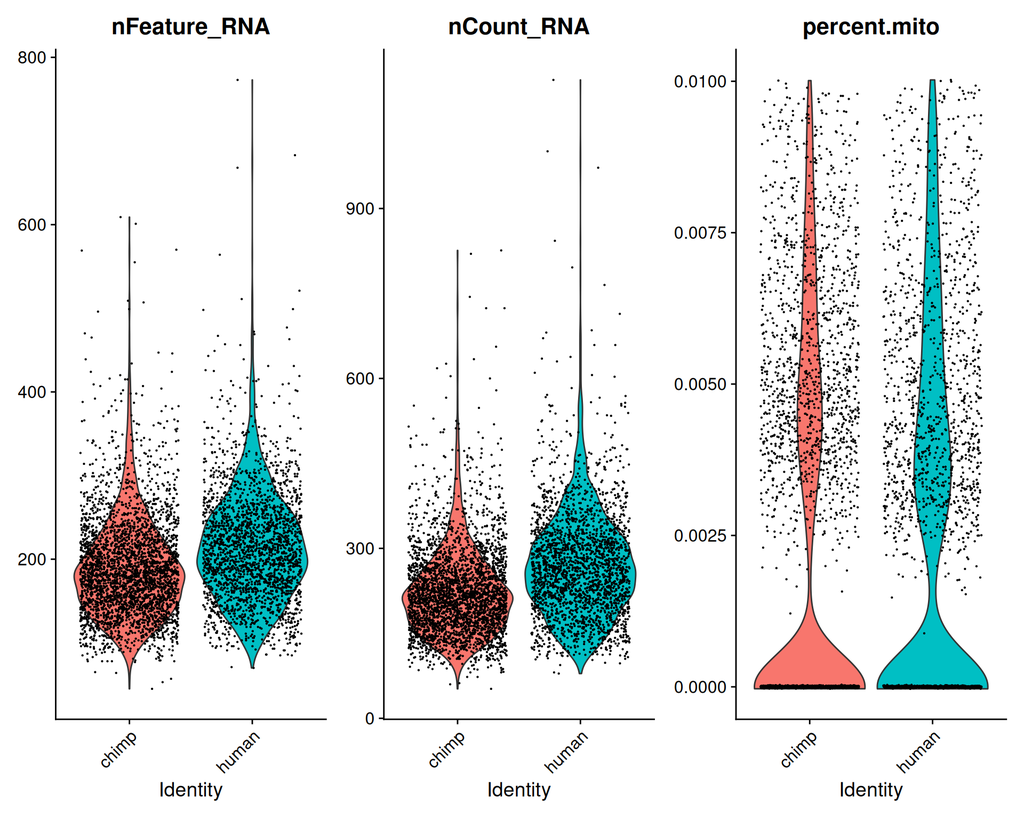

```r
mito.features <- grep(pattern = "^MT\\.", x = rownames(x = skm), value = TRUE)

# Calculate % of mitochondrial genes per cell
percent.mito <- Matrix::colSums(x = GetAssayData(object = skm, layer = 'counts')[mito.features, ]) / Matrix::colSums(x = GetAssayData(object = skm, layer = 'counts'))

# The [[ operator can add columns to object metadata, and is a great place to stash QC stats
skm[['percent.mito']] <- percent.mito
VlnPlot(object = skm, features = c("nFeature_RNA", "nCount_RNA", "percent.mito"), ncol = 3)
```

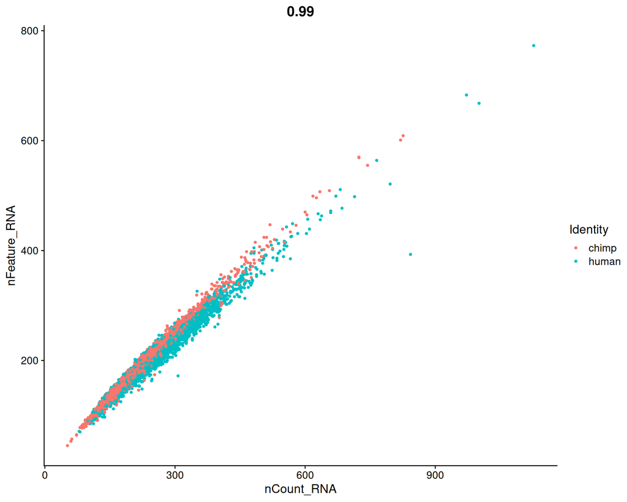

```r
FeatureScatter(object = skm, feature1 = "nCount_RNA", feature2 = "nFeature_RNA")
```

We conclude that larger library sizes (nCount_RNA) give more detected genes per cell (nFeature_RNA).

Now we will normalize the data. By default, Seurat employs a global-scaling normalization method “LogNormalize” that normalizes the feature expression measurements for each cell by the total expression, multiplies this by a scale factor (10,000 by default), and log-transforms the result. However, one can also use a more recent and intelligent SCTransform normalization, https://pubmed.ncbi.nlm.nih.gov/31870423/, that regresses out the dependence of gene expression of sequencing depth individually for lowly, moderately and highly expressed genes.

```r
skm <- NormalizeData(object = skm, normalization.method = "LogNormalize", scale.factor = 1e4)
```

```
## Normalizing layer: counts
```

Now we will identify Highly Variable Genes (HVGs) wich will be used for dimensionality reduction. FindVariableFeatures calculates the average expression and dispersion for each feature, places these features into bins, and then calculates a z-score for dispersion within each bin. This helps control for the relationship between variability and average expression.

```r
skm <- FindVariableFeatures(object = skm, nfeatures = dim(skm)[1])
```

```
## Finding variable features for layer counts
```

Thus we have 17676 Highly Variable Genes (HVGs) which we will use for further downstream analysis.

### Principal Component Analysis (PCA)

The single cell dataset likely contains “uninteresting” sources of variation. This could include not only technical noise, but batch effects, or even biological sources of variation (cell cycle stage). To mitigate the effect of these signals, Seurat constructs linear models to predict feature expression based on user-defined variables. The scaled z-scored residuals of these models are stored in the *scale.data* slot, and are used for dimensionality reduction and clustering.

```r
skm <- ScaleData(object = skm, features = rownames(x = skm), vars.to.regress = c("nCount_RNA","percent.mito"))
```

Next we will perform linear Dimensionality Reduction which is a Principal Component Analysis (PCA) in this case:

```r
skm <- RunPCA(object = skm, features = VariableFeatures(object = skm), verbose = FALSE)
```

We can see genes contributing to the loadings of the principal components. Let us now visualize loadings for the first two PCs:

```r
print(x = skm[['pca']], dims = 1:5, nfeatures = 5, projected = FALSE)
```

```
## PC_ 1
## Positive:  ABCA5, TRIM63, KLHL24, RBFOX1, ABCA10
## Negative:  EMC10, CTD.2545M3.8, MYBPC1, MIR1.1HG, AC074117.10
## PC_ 2
## Positive:  NOVA1, APOD, TNXB, ABCA8, COL6A1
## Negative:  TTN, NEB, NEAT1, TRDN, MIR133A1HG
## PC_ 3
## Positive:  TNNT3, ATP2A1, TPM1, MYH1, MYH2
## Negative:  MYH7B, TNNT1, ATP2A2, TPM3, XPO4
## PC_ 4
## Positive:  NOVA1, ABCA8, APOD, TNXB, CFD
## Negative:  HLA.B, EGFL7, HIF3A, HLA.E, B2M
## PC_ 5
## Positive:  NEXN, TECRL, PDK4, PFKFB3, TRIM63
## Negative:  ATP2A1, MYLPF, TRDN, GGT7, MYH2
```

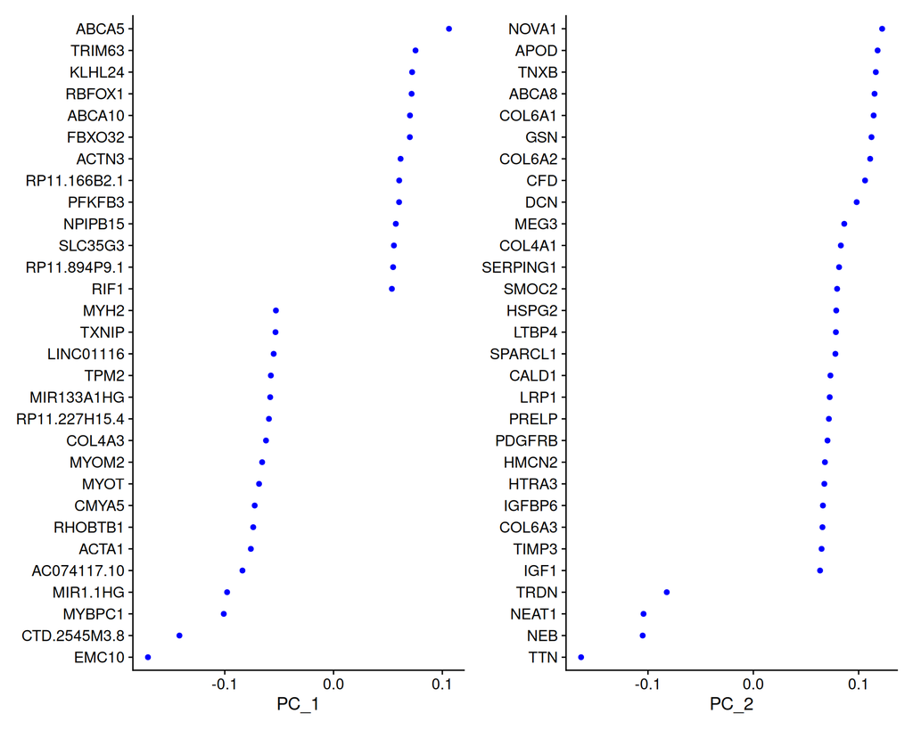

```r
VizDimLoadings(object = skm, dims = 1:2)
```

and display the PCA plot itself:

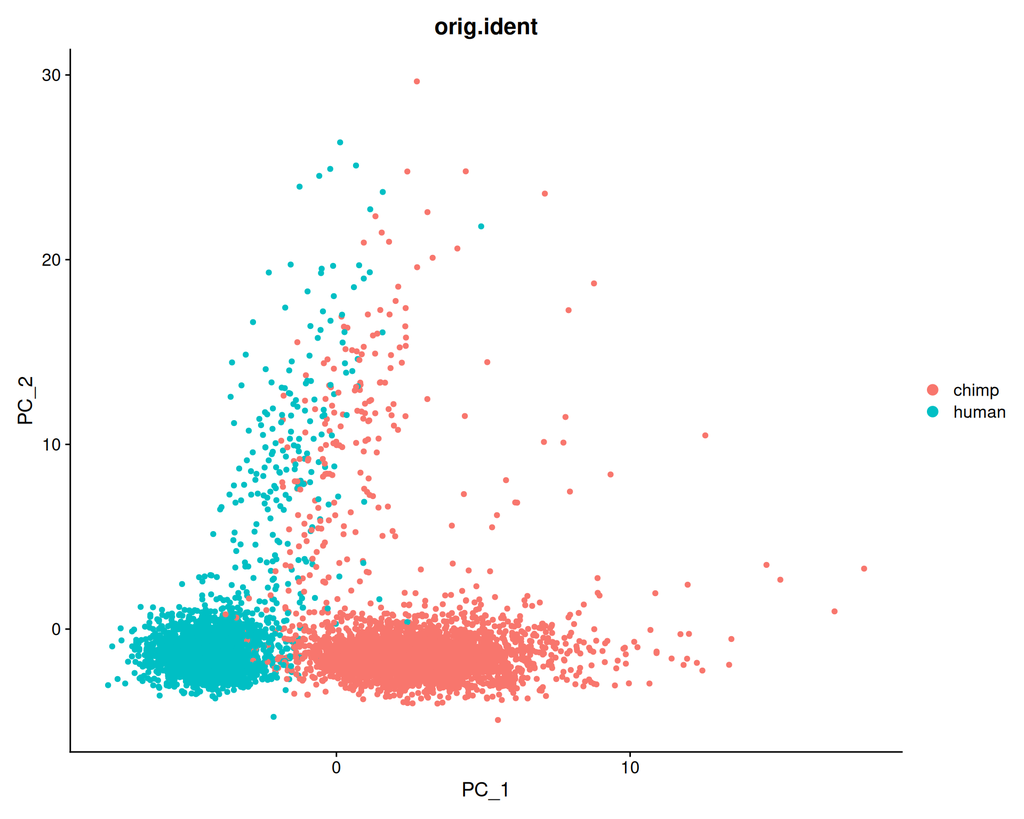

```r
DimPlot(object = skm, group.by="orig.ident", pt.size=1.2)
```

```r
skm <- ProjectDim(object = skm)
```

```
## PC_ 1
## Positive:  ABCA5, TRIM63, KLHL24, RBFOX1, ABCA10, FBXO32, ACTN3, RP11.166B2.1, PFKFB3, NPIPB15
##     SLC35G3, RP11.894P9.1, RIF1, AC005523.2, RP5.947P14.1, AAK1, LPIN1, FAM134B, ABCC5, PLIN5
## Negative:  EMC10, CTD.2545M3.8, MYBPC1, MIR1.1HG, AC074117.10, ACTA1, RHOBTB1, CMYA5, MYOT, MYOM2
##     COL4A3, RP11.227H15.4, MIR133A1HG, TPM2, LINC01116, TXNIP, MYH2, EHBP1L1, MYF6, DDX5
## PC_ 2
## Positive:  NOVA1, APOD, TNXB, ABCA8, COL6A1, GSN, COL6A2, CFD, DCN, MEG3
##     COL4A1, SERPING1, SMOC2, HSPG2, LTBP4, SPARCL1, CALD1, LRP1, PRELP, PDGFRB
## Negative:  TTN, NEB, NEAT1, TRDN, MIR133A1HG, MYBPC1, EMC10, NEXN, ABCA5, PDLIM3
##     FBXO32, YBX3, CMYA5, PDE4DIP, NRAP, PDLIM5, TNNT3, ATP1A2, OBSCN, CTD.2545M3.8
## PC_ 3
## Positive:  TNNT3, ATP2A1, TPM1, MYH1, MYH2, TNNI2, TNNC2, ABCA5, MYLPF, ACTN3
##     PFKFB3, TRIM63, GGT7, IGFN1, ENO3, MYBPC2, LPIN1, FAM166B, CMYA5, POMT2
## Negative:  MYH7B, TNNT1, ATP2A2, TPM3, XPO4, MYH7, TNNI1, USP54, MYBPC1, TECRL
##     PLIN5, CD36, LINC00958, PRSS45, LGR5, ATP1B4, AQP7, BEND7, CFLAR, MYL2
## PC_ 4
## Positive:  NOVA1, ABCA8, APOD, TNXB, CFD, COL6A1, DCN, COL6A2, SMOC2, COL6A3
##     HTRA3, MEG3, ADM, PRELP, GSN, SERPING1, ABCA9, LRP1, LTBP4, ADH1B
## Negative:  HLA.B, EGFL7, HIF3A, HLA.E, B2M, CAV1, TMSB10, BTNL9, IFITM3, FABP4
##     VWF, IGF2, RNASE1, ADGRF5, FLT1, CD74, EMCN, KLF2, XAF1, ITGA1
## PC_ 5
## Positive:  NEXN, TECRL, PDK4, PFKFB3, TRIM63, ABCA5, POMT2, FBXO32, LPIN1, FEZ2
##     YBX3, IL17D, CD36, NRAP, MYH7B, FAM134B, ZFAND5, NEAT1, UCP3, CCDC39
## Negative:  ATP2A1, MYLPF, TRDN, GGT7, MYH2, MYH1, AGL, TPM2, TPM1, MYL1
##     TNNT3, RYR3, ASB18, ATXN7L2, DISC1, AC007228.9, CASQ1, TNNI2, MYBPC2, LINC00958
```

### Dimensionality Reduction and Clustering

Seurat uses graph-based clustering algorithm similar to Shared Nearest Neighbor (SNN). This method embeds cells in a graph structure - for example a K-nearest neighbor (KNN) graph, with edges drawn between cells with similar gene expression patterns, and then attempts to partition this graph into highly interconnected ‘quasi-cliques’ or ‘communities’. We first construct a KNN graph based on the euclidean distance in PCA space, and refine the edge weights between any two cells based on the shared overlap in their local neighborhoods (Jaccard similarity). To cluster the cells, we apply modularity optimization techniques such as the Louvain algorithm (default).

```r
skm <- FindNeighbors(object = skm, dims = 1:5)
skm <- FindClusters(object = skm, resolution = 0.3)
```

```
## Modularity Optimizer version 1.3.0 by Ludo Waltman and Nees Jan van Eck
##
## Number of nodes: 5668
## Number of edges: 169881
##
## Running Louvain algorithm...
## Maximum modularity in 10 random starts: 0.9048
## Number of communities: 5
## Elapsed time: 0 seconds
```

Here we perform dimensionality reduction with tSNE and color the identified clusters by the graph-based clustering algorithm.

```r
opt_perp <- round(sqrt(length(skm@active.ident)),0)
opt_perp
```

```
## [1] 75
```

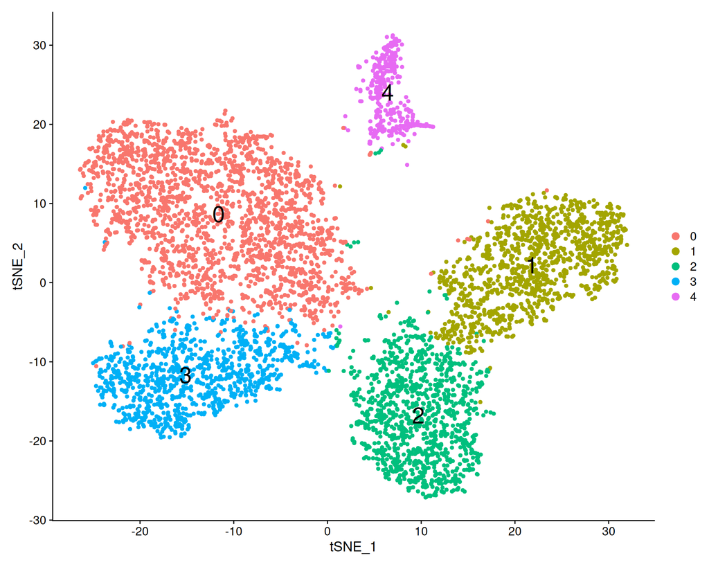

```r
skm <- RunTSNE(object = skm, dims = 1:5, perplexity = opt_perp, check_duplicates = FALSE)

DimPlot(object = skm, reduction = 'tsne', pt.size=1.2, label=TRUE, label.size=8)
```

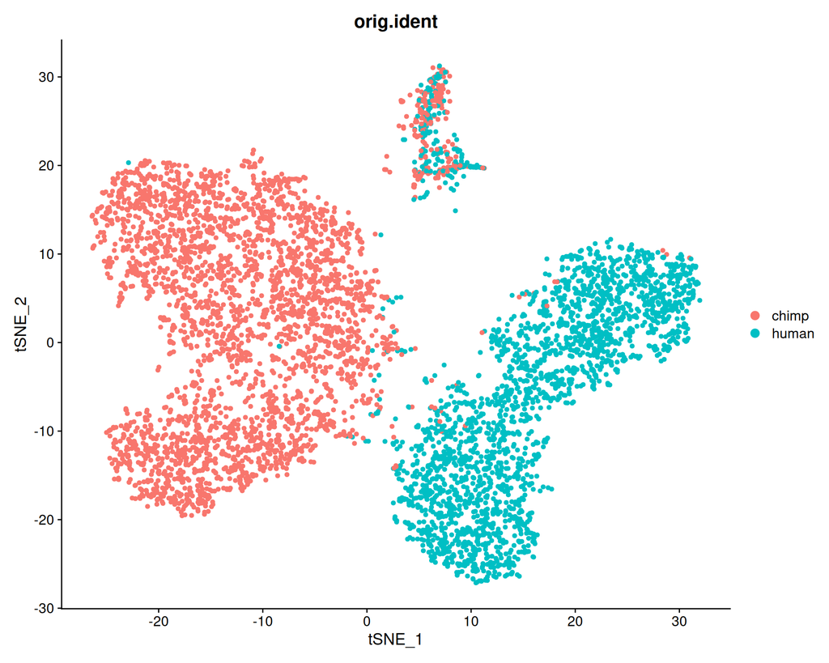

```r
DimPlot(object = skm, reduction = 'tsne', group.by="orig.ident", pt.size=1.2)
```

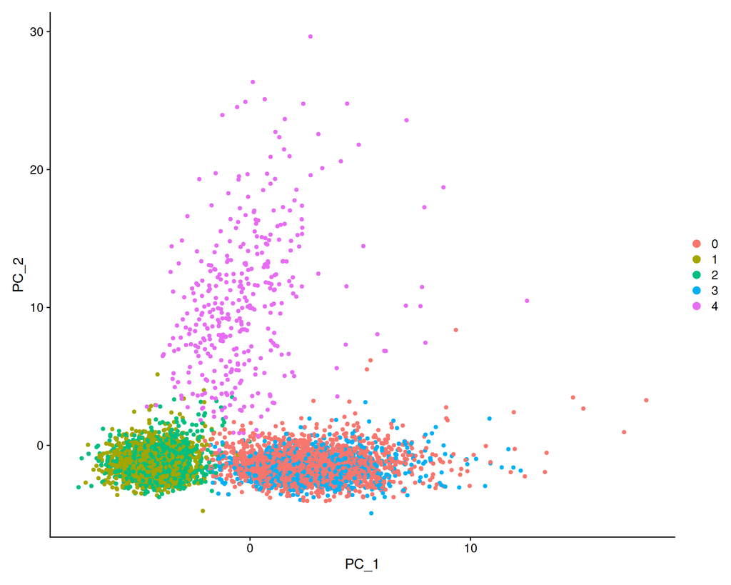

```r
DimPlot(object = skm, reduction = 'pca', pt.size=1.2)
```

Let us check the numbers of cells in each cluster:

```r
table(skm@active.ident)
```

```
##
##    0    1    2    3    4
## 2079 1175 1053  992  369
```

```r
cell_assignment<-data.frame(CELL=names(skm@active.ident),CLUSTER=as.numeric(as.character(skm@active.ident)))
print(head(cell_assignment))
```

```
##           CELL CLUSTER
## 1 C00001_chimp       3
## 2 C00004_human       2
## 3 C00006_chimp       0
## 4 C00007_chimp       0
## 5 C00008_chimp       3
## 6 C00009_human       1
```

```r
cell_human_assignment<-cell_assignment[cell_assignment$CLUSTER==1 | cell_assignment$CLUSTER==2,]
cell_human_assignment<-cell_human_assignment[grepl("human",as.character(cell_human_assignment$CELL))==TRUE,]
print(head(cell_human_assignment))
```

```
##            CELL CLUSTER
## 2  C00004_human       2
## 6  C00009_human       1
## 7  C00011_human       1
## 8  C00014_human       1
## 10 C00018_human       1
## 12 C00024_human       1
```

```r
expr_human<-subset(expr,select=colnames(expr)[colnames(expr)%in%as.character(cell_human_assignment$CELL)])

cell_chimp_assignment<-cell_assignment[cell_assignment$CLUSTER==0 | cell_assignment$CLUSTER==3,]
cell_chimp_assignment<-cell_chimp_assignment[grepl("chimp",as.character(cell_chimp_assignment$CELL))==TRUE,]
print(head(cell_chimp_assignment))
```

```
##            CELL CLUSTER
## 1  C00001_chimp       3
## 3  C00006_chimp       0
## 4  C00007_chimp       0
## 5  C00008_chimp       3
## 9  C00015_chimp       0
## 11 C00021_chimp       0
```

```r
expr_chimp<-subset(expr,select=colnames(expr)[colnames(expr)%in%as.character(cell_chimp_assignment$CELL)])
```

The clustering is not very transparent implying that more thorough filtering is needed, alternatively, the cells look biologically very similar. We can assign final labels to clusters based on their gene markers:

```r
new.cluster.ids <- c("Chimp Fast Twitch", "Human Fast Twitch", "Human Slow Twitch", "Chimp Slow Twitch", "Unclear Cells", "Poor Quality Cells")
names(x = new.cluster.ids) <- levels(x = skm)
skm <- RenameIdents(object = skm, new.cluster.ids)
```

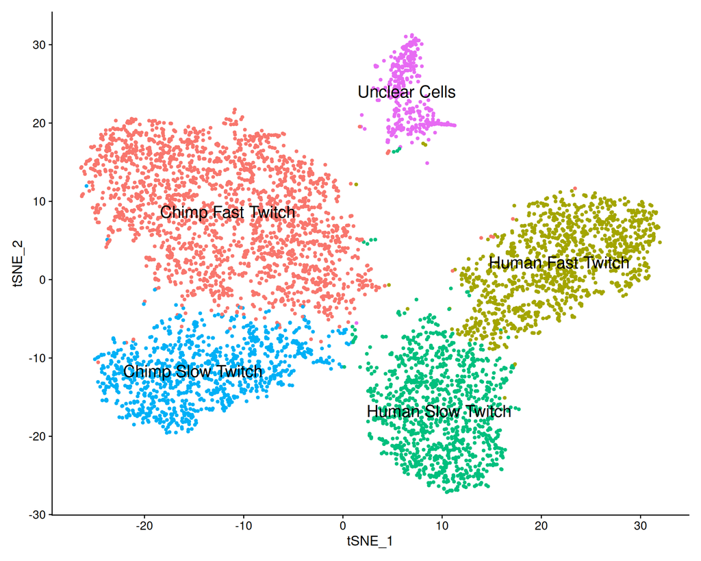

```r
DimPlot(object = skm, reduction = 'tsne', label = TRUE, pt.size=1, label.size=6) + NoLegend()
```

### Differential Gene Expression (DGE) Analysis with DESeq2

In this section, we compare human fast-twitch and slow-twitch skeletal muscle nuclei using the cluster annotation created above. In the original clustering, `CLUSTER == 1` corresponds to **Human Fast Twitch** and `CLUSTER == 2` corresponds to **Human Slow Twitch**. We use the original, un-normalized count matrix `expr`, not Seurat’s log-normalized expression values.

For this requested analysis, each nucleus is treated as one observation in DESeq2. This is useful as an exploratory cell-level comparison, but there is an important statistical limitation: nuclei from the same donor are not independent biological replicates. If the data include multiple donors, a model that accounts for donor-level replication (or a pseudobulk analysis) is generally needed for population-level inference. Treat the p-values here as potentially over-optimistic if donor identity is not modelled.

First, assemble the count matrix and confirm the cluster labels and number of nuclei in each group.

```r
library("DESeq2")
# The annotation table was created earlier in this notebook.
# CLUSTER 1 = Human Fast Twitch; CLUSTER 2 = Human Slow Twitch.
human_fibre_assignment <- cell_human_assignment[cell_human_assignment$CLUSTER %in% c(1, 2), ]

human_fibre_assignment$FIBRE_TYPE<-ifelse(human_fibre_assignment$CLUSTER == 1, "Human_Fast_Twitch", "Human_Slow_Twitch")

table(human_fibre_assignment$FIBRE_TYPE)
```

```
##
## Human_Fast_Twitch Human_Slow_Twitch
##              1166              1035
```

```r
head(human_fibre_assignment)
```

```
##            CELL CLUSTER        FIBRE_TYPE
## 2  C00004_human       2 Human_Slow_Twitch
## 6  C00009_human       1 Human_Fast_Twitch
## 7  C00011_human       1 Human_Fast_Twitch
## 8  C00014_human       1 Human_Fast_Twitch
## 10 C00018_human       1 Human_Fast_Twitch
## 12 C00024_human       1 Human_Fast_Twitch
```

Now select the corresponding columns from the raw expression matrix. Matching by cell name ensures that the count columns and the annotation rows are in exactly the same order.

```r
human_cells <- as.character(human_fibre_assignment$CELL)

# Keep only cells present in the expression matrix.
human_cells <- human_cells[human_cells %in% colnames(expr)]
human_fibre_assignment <- human_fibre_assignment[match(human_cells, human_fibre_assignment$CELL), ]

counts_human_fibres <- as.matrix(expr[, human_cells, drop = FALSE])
storage.mode(counts_human_fibres) <- "numeric"
counts_human_fibres[1:5,1:5]
```

```
##               C00004_human C00009_human C00011_human C00014_human C00018_human
## RP11.34P13.7             0            0            0            0            0
## FO538757.2               0            0            0            0            0
## AP006222.2               0            0            0            0            0
## RP4.669L17.10            0            0            0            0            0
## RP5.857K21.4             0            0            0            0            0
```

```r
dim(counts_human_fibres)
```

```
## [1] 18005  2201
```

```r
# DESeq2 requires non-negative integer counts.
stopifnot(all(is.finite(counts_human_fibres)))
stopifnot(all(counts_human_fibres >= 0))
stopifnot(all(abs(counts_human_fibres - round(counts_human_fibres)) < 1e-8))
counts_human_fibres <- round(counts_human_fibres)
storage.mode(counts_human_fibres) <- "integer"
counts_human_fibres[1:5,1:5]
```

```
##               C00004_human C00009_human C00011_human C00014_human C00018_human
## RP11.34P13.7             0            0            0            0            0
## FO538757.2               0            0            0            0            0
## AP006222.2               0            0            0            0            0
## RP4.669L17.10            0            0            0            0            0
## RP5.857K21.4             0            0            0            0            0
```

```r
dim(counts_human_fibres)
```

```
## [1] 18005  2201
```

```r
# Remove genes with no counts across the selected nuclei.
counts_human_fibres <- counts_human_fibres[rowSums(counts_human_fibres) > 0, , drop = FALSE]
counts_human_fibres[1:5,1:5]
```

```
##               C00004_human C00009_human C00011_human C00014_human C00018_human
## RP11.34P13.7             0            0            0            0            0
## FO538757.2               0            0            0            0            0
## AP006222.2               0            0            0            0            0
## RP4.669L17.10            0            0            0            0            0
## RP5.857K21.4             0            0            0            0            0
```

```r
dim(counts_human_fibres)
```

```
## [1] 14803  2201
```

```r
sample_info <- data.frame(row.names = human_fibre_assignment$CELL,fibre_type = factor(human_fibre_assignment$FIBRE_TYPE, levels = c("Human_Slow_Twitch", "Human_Fast_Twitch")))
head(sample_info)
```

```
##                     fibre_type
## C00004_human Human_Slow_Twitch
## C00009_human Human_Fast_Twitch
## C00011_human Human_Fast_Twitch
## C00014_human Human_Fast_Twitch
## C00018_human Human_Fast_Twitch
## C00024_human Human_Fast_Twitch
```

```r
stopifnot(identical(colnames(counts_human_fibres), rownames(sample_info)))
table(sample_info$fibre_type)
```

```
##
## Human_Slow_Twitch Human_Fast_Twitch
##              1035              1166
```

```r
dim(counts_human_fibres)
```

```
## [1] 14803  2201
```

We now fit the standard DESeq2 negative-binomial model. The contrast is **Human Fast Twitch versus Human Slow Twitch**. A positive log2 fold change means higher expression in fast-twitch nuclei; a negative value means higher expression in slow-twitch nuclei.

```r
dds <- DESeqDataSetFromMatrix(countData = counts_human_fibres, colData = sample_info, design = ~ fibre_type)

# Filter out genes with very little information for the comparison.
keep <- rowSums(counts(dds) >= 5) >= 1
dds <- dds[keep, ]

dds <- DESeq(dds, sfType = "poscounts")
res <- results(dds, contrast = c("fibre_type", "Human_Fast_Twitch", "Human_Slow_Twitch"))

res_df <- as.data.frame(res)
res_df$gene <- rownames(res_df)
res_df <- res_df[order(res_df$padj, na.last = TRUE), ]

# Show the most significant genes.
head(res_df[, c("gene", "baseMean", "log2FoldChange", "lfcSE", "stat", "pvalue", "padj")], 20)
```

```
##            gene  baseMean log2FoldChange      lfcSE       stat        pvalue
## TNNT3     TNNT3 1.9955305      2.1432497 0.06175936  34.703236 7.040709e-264
## TNNT1     TNNT1 2.0556382     -1.8062958 0.05733123 -31.506313 7.118473e-218
## ATP2A1   ATP2A1 0.8585798      2.1718161 0.07885156  27.543097 5.353503e-167
## ATP2A2   ATP2A2 0.6680123     -1.9496069 0.07963606 -24.481458 2.327927e-132
## MYH7B     MYH7B 0.5353147     -2.2201278 0.09218333 -24.083832 3.692690e-128
## MYBPC1   MYBPC1 3.2832732     -1.0214240 0.04273092 -23.903631 2.807692e-126
## MYH2       MYH2 0.8487799      1.9351198 0.08387852  23.070503 9.159221e-118
## MYH7       MYH7 1.0581000     -1.6867533 0.07576659 -22.262494 8.536353e-110
## TPM3       TPM3 0.5208954     -1.6225321 0.08301151 -19.545868  4.473166e-85
## MYLPF     MYLPF 0.8568083      1.4804957 0.07867378  18.818159  5.361503e-79
## TNNI1     TNNI1 0.7304000     -1.3924105 0.07934895 -17.547939  6.167831e-69
## TPM1       TPM1 0.5848560      1.4763073 0.08635579  17.095638  1.599356e-65
## TNNI2     TNNI2 0.6073068      1.3500049 0.08355822  16.156459  1.022698e-58
## TNNC2     TNNC2 2.0259680      0.8401915 0.05311153  15.819381  2.287316e-56
## NEB         NEB 3.1333579     -0.6222564 0.04311790 -14.431509  3.278290e-47
## MYH1       MYH1 0.5223150      1.6035030 0.11672950  13.736914  6.102176e-43
## TNNC1     TNNC1 0.8201298     -0.9775678 0.07391989 -13.224692  6.319586e-40
## EMC10     EMC10 5.9667717      0.5109170 0.03922720  13.024560  8.871064e-39
## MYL2       MYL2 0.7947632     -1.0037554 0.07943466 -12.636240  1.332769e-36
## RHOBTB1 RHOBTB1 0.4225444      0.8450871 0.09369020   9.020017  1.880610e-19
##                  padj
## TNNT3   5.562160e-262
## TNNT1   2.811797e-216
## ATP2A1  1.409756e-165
## ATP2A2  4.597655e-131
## MYH7B   5.834450e-127
## MYBPC1  3.696794e-125
## MYH2    1.033684e-116
## MYH7    8.429648e-109
## TPM3     3.926445e-84
## MYLPF    4.235587e-78
## TNNI1    4.429624e-68
## TPM1     1.052909e-64
## TNNI2    6.214855e-58
## TNNC2    1.290700e-55
## NEB      1.726566e-46
## MYH1     3.012949e-42
## TNNC1    2.936749e-39
## EMC10    3.893412e-38
## MYL2     5.541513e-36
## RHOBTB1  7.428408e-19
```

```r
# Number of genes passing a nominal 5% adjusted-p-value threshold.
sum(res_df$padj < 0.05, na.rm = TRUE)
```

```
## [1] 56
```

Visualise the expression of the expected fibre-type markers. These genes are useful biological checks, but the direction and significance should be determined from the actual output rather than assumed in advance.

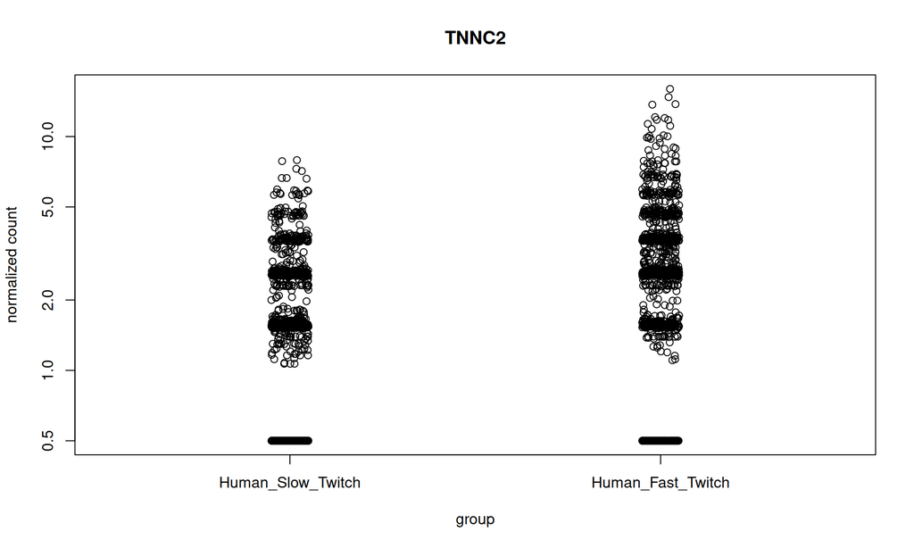

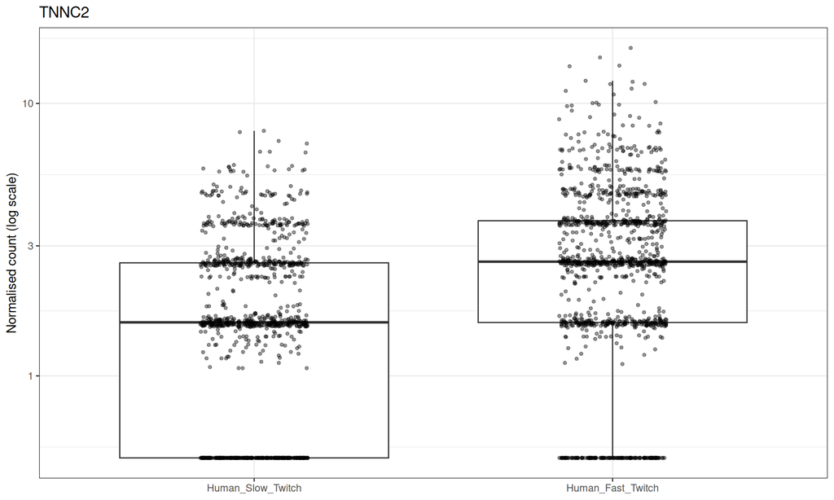

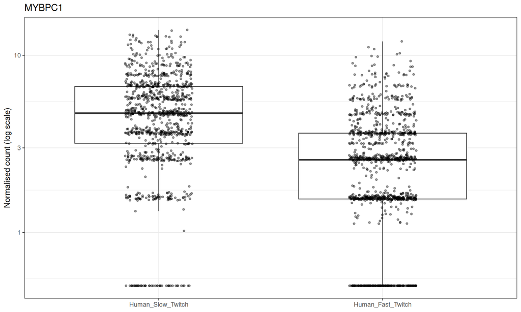

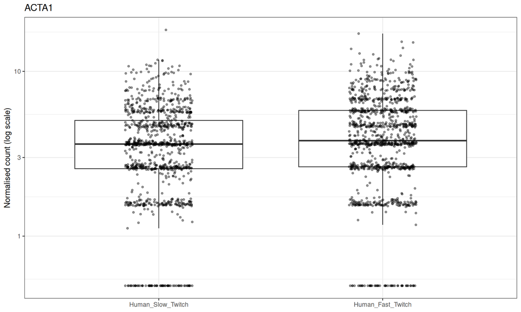

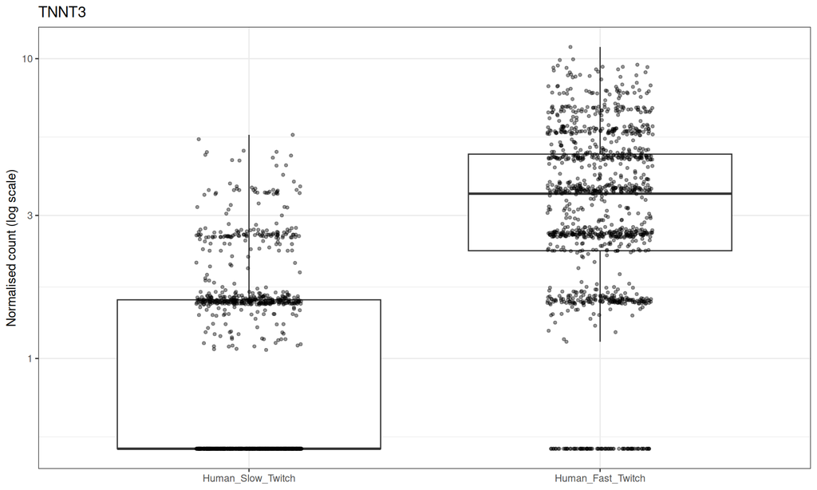

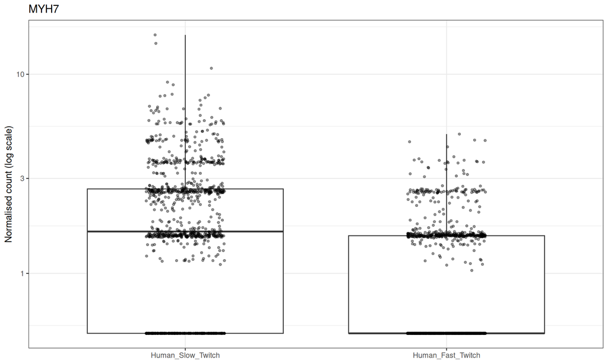

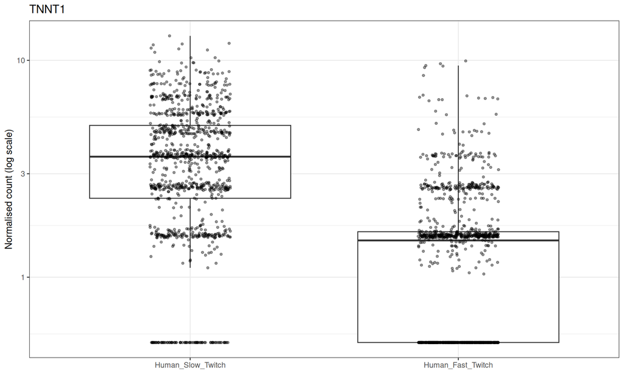

```r
marker_genes <- intersect(c("TNNC2", "MYBPC1", "ACTA1", "TNNT3", "MYH7", "TNNT1"), rownames(dds))

if (length(marker_genes) > 0) {
  plotCounts(dds, gene = marker_genes[1],
             intgroup = "fibre_type", returnData = FALSE)
  # A separate plot for each marker makes the group distributions easier to inspect.
  for (gene in marker_genes) {
    print(
      ggplot2::ggplot(
        plotCounts(dds, gene = gene, intgroup = "fibre_type",
                   returnData = TRUE),
        ggplot2::aes(x = fibre_type, y = count)
      ) +
        ggplot2::geom_boxplot(outlier.shape = NA) +
        ggplot2::geom_jitter(width = 0.15, alpha = 0.4, size = 1) +
        ggplot2::scale_y_log10() +
        ggplot2::labs(title = gene, x = NULL,
                      y = "Normalised count (log scale)") +
        ggplot2::theme_bw()
    )
  }
}
```

A volcano plot provides a compact overview of effect size and statistical evidence.

```r
library("ggrepel")
```

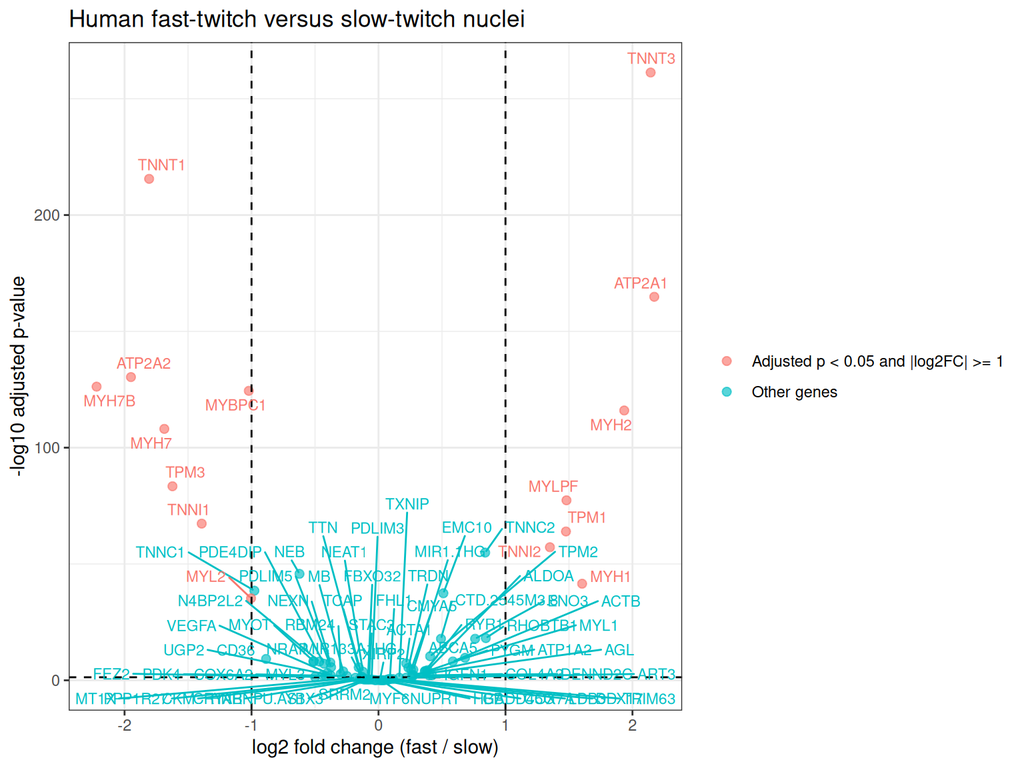

```r
res_plot <- res_df
res_plot$label <- res_plot$gene
res_plot$neg_log10_padj <- -log10(pmax(res_plot$padj, .Machine$double.xmin))
res_plot$significance <- ifelse(!is.na(res_plot$padj) & res_plot$padj < 0.05 & abs(res_plot$log2FoldChange) >= 1, "Adjusted p < 0.05 and |log2FC| >= 1", "Other genes")

ggplot2::ggplot(
  res_plot[is.finite(res_plot$log2FoldChange) &
             is.finite(res_plot$neg_log10_padj), ],
  ggplot2::aes(x = log2FoldChange, y = neg_log10_padj,
               colour = significance)) +
  ggplot2::geom_point(alpha = 0.65, size = 2) +
  ggplot2::geom_vline(xintercept = c(-1, 1), linetype = "dashed") +
  ggplot2::geom_hline(yintercept = -log10(0.05), linetype = "dashed") +
  ggrepel::geom_text_repel(ggplot2::aes(label = label), size = 3, max.overlaps = Inf, show.legend = FALSE, na.rm = TRUE) +
  ggplot2::labs(
    title = "Human fast-twitch versus slow-twitch nuclei",
    x = "log2 fold change (fast / slow)",
    y = "-log10 adjusted p-value",
    colour = NULL
  ) +
  ggplot2::theme_bw()
```

### Pathway and Gene Set Enrichment (GSEA) Analysis

Differential expression gives a gene-by-gene result. Pathway analysis asks whether genes belonging to a known biological process are over-represented among the differentially expressed genes, while Gene Set Enrichment Analysis (GSEA) tests whether members of a pathway tend to accumulate near the top or bottom of a ranked genome-wide gene list. GSEA can detect coordinated shifts even when individual genes do not pass a strict significance threshold.

We will use two complementary approaches:

1. **KEGG over-representation analysis (ORA)** on genes selected using adjusted p-values.
2. **GSEA with `fgsea`** using MSigDB Hallmark gene sets and the DESeq2 Wald statistic to rank genes. This avoids choosing an arbitrary cut-off for the GSEA input.

Install any missing packages once, if needed, before running the notebook.

```r
# Run only if a package is missing:
# install.packages(c("BiocManager", "msigdbr", "fgsea", "ggplot2"))
# BiocManager::install(c("clusterProfiler", "org.Hs.eg.db"))

library("clusterProfiler")
library("org.Hs.eg.db")
library("msigdbr")
library("fgsea")
library("ggplot2")
```

#### KEGG pathway over-representation analysis

KEGG pathway analysis requires Entrez Gene identifiers. We map the significant gene symbols to Entrez IDs and test whether KEGG pathways contain more significant genes than expected. This analysis depends on the significance threshold, so report the threshold together with the results.

```
## Reading KEGG annotation online: "https://rest.kegg.jp/link/hsa/pathway"...
```

```
## Reading KEGG annotation online: "https://rest.kegg.jp/list/pathway/hsa"...
```

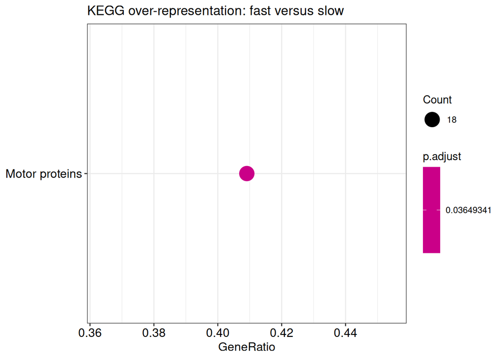

```r
significant_genes <- res_df$gene[!is.na(res_df$padj) & res_df$padj < 0.1]

if (length(significant_genes) >= 5) {
  gene_map <- bitr(unique(significant_genes),fromType = "SYMBOL",toType = "ENTREZID",OrgDb = org.Hs.eg.db)

  # Use all tested genes as the background universe.
  background_map <- bitr(rownames(dds),fromType = "SYMBOL",toType = "ENTREZID",OrgDb = org.Hs.eg.db)

  kegg_ora <- enrichKEGG(gene = unique(gene_map$ENTREZID),universe = unique(background_map$ENTREZID),organism = "hsa",pAdjustMethod = "BH",qvalueCutoff = 0.05, minGSSize = 5,maxGSSize = 2000)

  as.data.frame(kegg_ora) |> head(20)
  if (nrow(as.data.frame(kegg_ora)) > 0) {
    print(dotplot(kegg_ora, showCategory = 15) +
            ggplot2::ggtitle("KEGG over-representation: fast versus slow"))
  }
} else {
  message("Fewer than five genes passed adjusted p < 0.05; KEGG ORA skipped. ",
          "Consider the GSEA results below, which use all ranked genes.")
}
```

#### Gene Set Enrichment Analysis with fgsea

For GSEA, we rank every tested gene by the signed DESeq2 Wald statistic. Positive values indicate higher expression in fast-twitch nuclei; negative values indicate higher expression in slow-twitch nuclei. The Hallmark collection contains curated gene sets representing broad biological processes. Here we use it as a robust, interpretable starting point; other MSigDB collections can be substituted.

```r
# Prepare a ranked vector, retaining one score per gene and excluding missing scores.
ranked_genes <- res_df$stat
names(ranked_genes) <- res_df$gene
ranked_genes <- ranked_genes[is.finite(ranked_genes)]
ranked_genes <- sort(ranked_genes, decreasing = TRUE)

# Remove duplicated gene symbols if any occur.
ranked_genes <- ranked_genes[!duplicated(names(ranked_genes))]

# Obtain human Hallmark gene sets from MSigDB.
hallmark_tbl <- msigdbr(species = "Homo sapiens", collection = "H")

hallmark_pathways <- split(hallmark_tbl$gene_symbol, hallmark_tbl$gs_name)

set.seed(1)
fgsea_res <- fgseaMultilevel(pathways = hallmark_pathways,stats = ranked_genes, minSize = 3, maxSize = 500)

fgsea_res <- as.data.frame(fgsea_res)
fgsea_res <- fgsea_res[order(fgsea_res$padj), ]

fgsea_res[, c("pathway", "NES", "pval", "padj", "size")] |> head(20)
```

```
##                                       pathway        NES      pval      padj
## 2  HALLMARK_EPITHELIAL_MESENCHYMAL_TRANSITION  1.1503453 0.3295019 0.6373551
## 6                  HALLMARK_KRAS_SIGNALING_DN -1.1882161 0.2880658 0.6373551
## 7                   HALLMARK_MTORC1_SIGNALING -1.3151676 0.1363636 0.6373551
## 8                         HALLMARK_MYOGENESIS  1.0399439 0.3824131 0.6373551
## 9                        HALLMARK_P53_PATHWAY -1.2880850 0.1632231 0.6373551
## 10             HALLMARK_XENOBIOTIC_METABOLISM -1.2457818 0.2139918 0.6373551
## 1                    HALLMARK_APICAL_JUNCTION -0.5508676 0.9382716 0.9864603
## 3              HALLMARK_FATTY_ACID_METABOLISM  0.6946541 0.8333333 0.9864603
## 4                         HALLMARK_GLYCOLYSIS  0.4525567 0.9864603 0.9864603
## 5                            HALLMARK_HYPOXIA  0.8393240 0.7049808 0.9864603
##    size
## 2     3
## 6     4
## 7     3
## 8    31
## 9     3
## 10    4
## 1     4
## 3     3
## 4     4
## 5     5
```

Plot the most significant gene sets. A positive Normalized Enrichment Score (NES) means that the pathway tends to be enriched among genes expressed more highly in fast-twitch nuclei; a negative NES means enrichment toward slow-twitch nuclei.

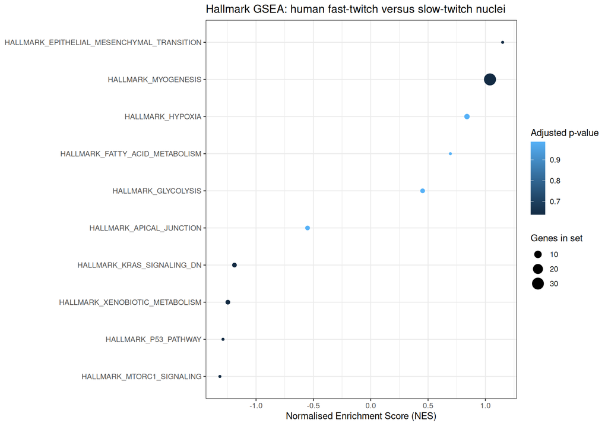

```r
fgsea_sig <- fgsea_res[!is.na(fgsea_res$padj) & fgsea_res$padj < 1, ]

if (nrow(fgsea_sig) > 0) {
  fgsea_sig <- fgsea_sig[order(abs(fgsea_sig$NES), decreasing = TRUE), ]
  fgsea_top <- head(fgsea_sig, 20)
  fgsea_top$pathway <- factor(
    fgsea_top$pathway,
    levels = fgsea_top$pathway[order(fgsea_top$NES)]
  )

  print(
    ggplot2::ggplot(
      fgsea_top,
      ggplot2::aes(x = NES, y = pathway, size = size, colour = padj)
    ) +
      ggplot2::geom_point() +
      ggplot2::labs(
        title = "Hallmark GSEA: human fast-twitch versus slow-twitch nuclei",
        x = "Normalised Enrichment Score (NES)",
        y = NULL,
        colour = "Adjusted p-value",
        size = "Genes in set"
      ) +
      ggplot2::theme_bw()
  )
} else {
  message("No Hallmark gene sets passed adjusted p < 0.05. ",
          "Inspect the top-ranked pathways cautiously, without treating them as significant.")
}
```

For a closer look at an individual pathway, choose one of the pathway names in `fgsea_res$pathway`. The enrichment plot shows whether genes in that set concentrate toward the fast-twitch or slow-twitch end of the ranked list.

```
## Top-ranked pathway: HALLMARK_EPITHELIAL_MESENCHYMAL_TRANSITION
```

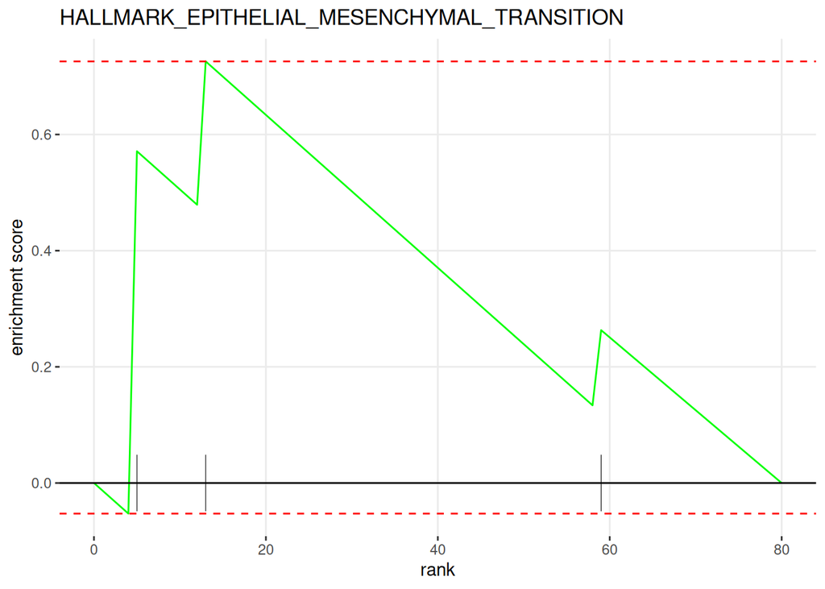

```r
if (nrow(fgsea_res) > 0) {
  best_pathway <- fgsea_res$pathway[1]
  message("Top-ranked pathway: ", best_pathway)
  print(fgsea::plotEnrichment(
    hallmark_pathways[[best_pathway]],
    ranked_genes
  ) + ggplot2::ggtitle(best_pathway))
}
```

#### How to discuss the pathway results

Use the actual `kegg_ora` and `fgsea_res` output after running the notebook; the pathway results cannot be known from the notebook code alone. Focus on:

- whether significant pathways are biologically consistent with contractile fibre identity, calcium handling, energy metabolism, and muscle-fibre specialisation;
- whether the NES direction agrees with the genes driving the fast-versus-slow contrast;
- whether the same biological theme appears in both KEGG ORA and fgsea, which provides complementary support;
- the adjusted p-values, pathway sizes, and leading-edge genes, rather than pathway names alone.

A pathway result is an enrichment signal, not proof that the pathway is activated or inhibited. Also, because the requested DESeq2 model treats individual nuclei as independent observations, the p-values and downstream enrichment significance may be anti-conservative if donor-to-donor variability is not accounted for. Interpret the findings as exploratory unless the biological replication structure supports this model.